# MaxRuehle

```r
library(dplyr)
```

```r
library(ggplot2)
library(lubridate)
library(tidyverse)
library(readxl)
acc <- read.csv("https://raw.githubusercontent.com/xdaiISU/ds202materials/master/hwlabs/fars2017/accident.csv", stringsAsFactors = FALSE)
```

Part one: Accident data

Are there some days of the week where more accidents happen than on others (use variable DAY_WEEK)?

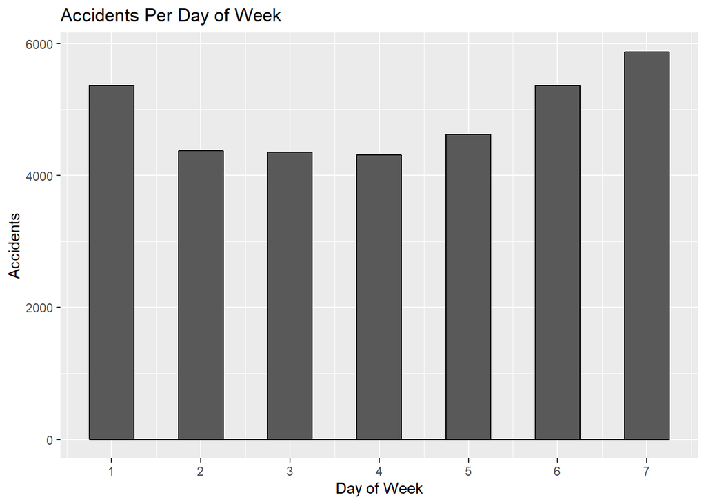

```r
ggplot(acc, aes(x=DAY_WEEK)) + geom_histogram(color="black", binwidth = .5) + xlab("Day of Week") + ylab("Accidents") + ggtitle("Accidents Per Day of Week") + scale_x_continuous(breaks=seq(1,7,1))
```

```r
#Lots of accidents are happening on Friday, Saturday, and Sunday. This is the weekend so more people are usually driving then.
```

What time of the day do accidents happen (use variable HOUR)?

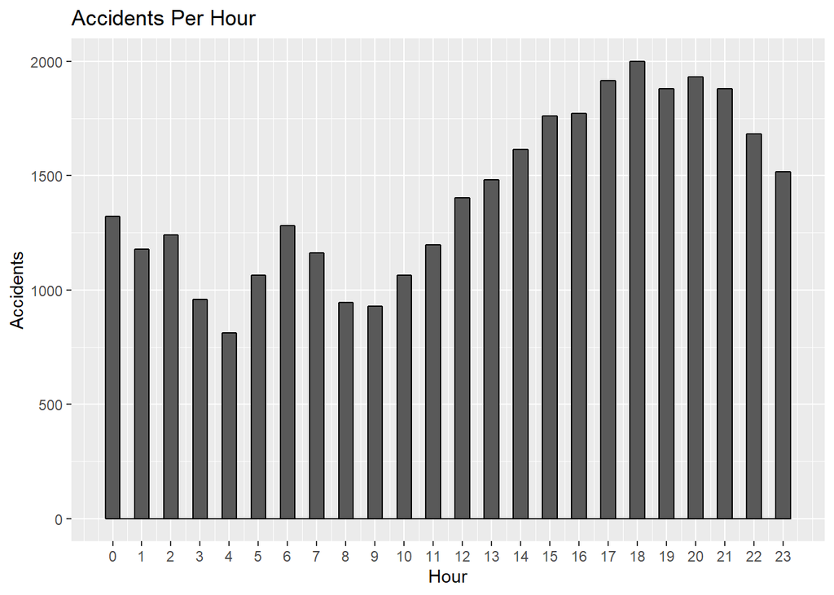

```r
acc <- acc[!(acc$HOUR == "99"),] # For some reason there was a value at 99 hours.
ggplot(acc, aes(x=HOUR)) + geom_histogram(color="black", binwidth = .5) + scale_x_continuous(breaks=seq(0,23,1)) + xlab("Hour") + ylab("Accidents") + ggtitle("Accidents Per Hour")
```

```r
#Lots of accidents are happening around the 17-19 hour range. This is about 5pm to 7-pm, usually rush hour where there is lots of traffic and more chances to get into accidents.
```

What is the number of accidents with at least one drunk driver (use variable DRUNK_DR)?

```r
accdd <- filter(acc, DRUNK_DR > 0)
dim(accdd)
```

```
## [1] 8667   52
```

```r
#There are 8667 accidents that involve at least one drunk driver
```

Part two: Connecting data

Load the person table. Identify drivers (PER_TYP == 1, see fars manual) and subset on them. Join accident and driver table (work out which variable(s) to use). Tally the number of accidents by day of the week (DAY_WEEK), hour of the day (HOUR) and gender (SEX). Visualize the results!

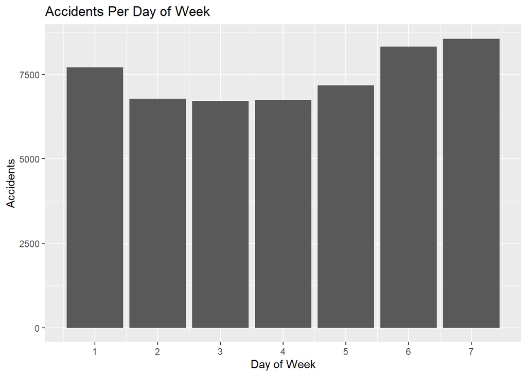

```r
per <- read.csv("https://raw.githubusercontent.com/xdaiISU/ds202materials/master/hwlabs/fars2017/person.csv", stringsAsFactors = FALSE)

drivers <- per %>% filter(PER_TYP == 1)

drivers %>% select(-c(HOUR)) %>% left_join(acc, by="ST_CASE") %>% group_by(DAY_WEEK) %>% summarise(count = n()) %>% ggplot(aes(x=DAY_WEEK)) + scale_x_continuous(breaks=seq(1,7,1)) + geom_bar(aes(weight=count)) + xlab("Day of Week") + ylab("Accidents") + ggtitle("Accidents Per Day of Week")
```